# Correction to: Habitat adaptation mediates the influence of leaf traits on canopy productivity: evidence from a tropical freshwater swamp forest

Draft erratum, with the corrected analysis and notes for co-authors

06 October 2026

**About this document (not part of the erratum).** This is a draft correction to Lam et al. (2022, *Ecosystems* 25: 1006–1019), written as it might be submitted to the journal, followed by afternotes for the co-authors that show how each correction changes the results. All numbers are computed on knitting from the original data. The published analysis is reproduced in `historical_reproduction.Rmd`.

This version reports the corrected analysis with the two *Calophyllum tetrapterum* (CTE) leaf samples treated as **fresh leaves** (scenario B2 in the afternotes). Whether these samples were fresh is unresolved, and it matters for the C:N result (Afternote 5); the document can be re-knitted for the other case. Line numbers (“l.”) refer to the accepted manuscript (https://eprints.soton.ac.uk/451090/).

# Correction to: Habitat adaptation mediates the influence of leaf traits on canopy productivity: evidence from a tropical freshwater swamp forest

Weng Ngai Lam, Pin Jia Chan, Ying Ying Ting, Hong Jhun Sim, Jun Jie Lian, Rie Chong, Nur Estya Rahman, Lorraine Wen Ai Tan, Qian Yi Ho, Zhongyu Chiam, Srishti Arora, Hao Ran Lai, Sorain J. Ramchunder, Kelvin S.-H. Peh, Yixiong Cai, Kwek Yan Chong

Correction to: *Ecosystems* (2022) 25: 1006–1019, https://doi.org/10.1007/s10021-021-00697-7

In the original article, the leaf carbon:nitrogen (C:N) ratio of each species was calculated as the mean over all of its CHNS samples. For 12 of the 25 study species these included senesced as well as fresh leaves, and one species, *Pentace triptera*, was represented by senesced leaves only. This contradicts the Methods, which state that C and N were measured on fresh leaves, and it affects the principal component analysis and every structural equation model (SEM) that used C:N or the principal components. We have repeated these analyses with C:N ratios calculated from fresh-leaf samples only. Because the SEMs are compared by AICc, which requires a common data set, *Pentace triptera* was excluded from all SEMs.

In repeating the analyses, we also corrected three further errors: (i) one species–plot combination (*Madhuca* in plot Q6) had been omitted because the trees in that plot were recorded under a different name for the same taxon; (ii) the C:N ratio of *Calophyllum tetrapterum* had been replaced by the mean of the other species, and is now its measured value; and (iii) one of the 108 SEMs (with plot type, biological hypothesis i, SLA) had been specified with the wrong direction of the trait–habitat path. Correction (iii) does not affect any reported result.

The main conclusions are unchanged. Biological hypothesis vi, that leaf traits give rise to habitat adaptations which in turn constrain canopy productivity, remains by far the best supported, and the effects of SLA, leaf thickness and PC1 on swamp adaptation are essentially unchanged. The positive association between leaf C:N ratio and swamp adaptation is weaker than originally reported (coefficient = 0.006; 95% CI = [0.000, 0.012], compared with coefficient = 0.009; 95% CI = [0.004, 0.013] originally), and the statements about C:N have been qualified accordingly. The total canopy production estimates, the comparison of swamp and non-swamp plots and the phenology analysis (Figs. 2 and 3) did not use leaf traits and are unaffected. The corrections are listed below.

## Abstract

- “69 tree species–plot combinations” (l. 14) should read “68 tree species–plot combinations”.
- The traits listed as associated with more conservative resource acquisition strategies (l. 16–17) should read “viz., low specific leaf area and thicker leaves, and to a lesser extent a high leaf C:N ratio”.

## Methods

- At the end of the paragraph on leaf traits (l. 182), the following should be added: “C:N ratios were calculated as the mean of the per-sample C:N ratios of fresh leaves. *Pentace triptera*, for which only senesced leaves were analysed, was excluded from the structural equation models.”
- In the description of the species canopy productivity analysis (l. 214 and 229), “25 tree species” should read “24 tree species”, and “a total of 69 species–plot combinations” should read “a total of 68 species–plot combinations”.
- The following should be added after the description of the swamp indicator value (SIV): “SIV was square-root transformed before analysis.”
- “All statistical analyses were performed in R ver. 3.4.0” (l. 282) should read “The structural equation models were fitted in R ver. 4.3.3 (R Core Team 2024) using piecewiseSEM ver. 2.1.2”.

## Results

Under *Species canopy productivity*, the three paragraphs (l. 310–337) should read as follows.

> All models considered, the best-supported SEMs again represented biological hypothesis vi, that leaf traits give rise to habitat adaptations which in turn constrain canopy productivity (Fig. 1). In the most parsimonious model (the one ranked first, with ΔAICc = 0), leaf traits were represented by PC1, which had a positive effect on SIV (coefficient = 0.07; 95% CI = [0.04, 0.11]). Swamp adaptation (SIV) in turn had a weak negative effect on canopy productivity (coefficient = -1.19; 95% CI = [-3.99, 1.62]). Thus, PC1 had a negative (0.07 × -1.19 = -0.09) indirect effect on canopy productivity.

> Other models of biological hypothesis vi differed only in the leaf trait included: SLA (second-ranked model) had a negative effect on SIV (coefficient = -0.29; 95% CI = [-0.41, -0.17]) and thus a positive (0.35) indirect effect on canopy productivity; leaf thickness (LT) (fifth-ranked model) had a positive effect on SIV (coefficient = 1.11; 95% CI = [0.37, 1.86]) and thus a negative (-1.32) indirect effect on canopy productivity; C:N ratio (ninth-ranked model) had a positive effect on SIV (coefficient = 0.006; 95% CI = [0.000, 0.012]) and thus a negative (-0.008) indirect effect on canopy productivity. Biological hypothesis vi had a summed Akaike weight of 54.1%, far greater than that of any competing hypothesis (Fig. 5).

> The effect of basal area on canopy production was strongly positive, with an estimated effect of 0.92 (95% CI = [0.59, 1.26]) in the top-ranked model, and a similar estimate across all models. Models containing plot type as a fixed effect in the canopy production component model were generally poor fits to the data: the highest-ranked such model had a ΔAICc of 9.32 and a weight of only 0.002 (Table 1).

## Discussion

- “low SLA, high leaf C:N ratio, and thicker leaves” (l. 368–369) should read “low SLA and thicker leaves, and to a lesser extent a high leaf C:N ratio”.
- “biological hypotheses vi and i; Fig. 4” (l. 413) should refer to Fig. 5.
- “the sixth-ranked model; Table 1” (l. 419), referring to the LDMC model of biological hypothesis ii, should read “the eighth-ranked model”.
- “leaf thickness and C:N ratio (Luo and others, 2005) had an indirect negative effect” (l. 397–398) should read “leaf thickness (Luo and others, 2005) had an indirect negative effect, and C:N ratio a very weak one (-0.008)”.

## Figures and tables

- The caption of Fig. 3b, “The number of rain days in a month during the same period” (l. 687), should read “Mean daily temperature over the 30 days preceding each collection date”.
- Table 1, Fig. 4 and Fig. 5 are replaced by the corrected versions below. In Fig. 4b the y-axis shows the square root of the swamp indicator value.
- Tables S1 and S3 in the Supplementary Information are replaced by the corrected versions below.

**Table 1** (corrected). Top ten models, and the top model containing the term Plot type, of the 108 SEMs fitted to 68 species–plot combinations of 24 species.

| Rank | Models | Biological hypothesis | R² (%) | Fisher’s C | AICc | ΔAICc | Weight |
| --- | --- | --- | --- | --- | --- | --- | --- |
| 1 | Canopy production ~ BA + SIV<br>SIV ~ PC1 | vi | 34.96<br>22.49 | 0.382 | 27.18 | 0.00 | 0.226 |
| 2 | Canopy production ~ BA + SIV<br>SIV ~ SLA | vi | 34.96<br>26.31 | 0.653 | 27.51 | 0.33 | 0.191 |
| 3 | Canopy production ~ BA + LDMC<br>LDMC ~ SIV | vii | 33.20<br>1.85 | 1.858 | 28.97 | 1.79 | 0.092 |
| 4 | Canopy production ~ BA + PC2<br>PC2 ~ SIV | vii | 32.97<br>2.09 | 2.327 | 29.54 | 2.36 | 0.069 |
| 5 | Canopy production ~ BA + SIV<br>SIV ~ LT | vi | 34.96<br>11.54 | 2.583 | 29.85 | 2.67 | 0.059 |
| 6 | Canopy production ~ BA + SIV + PC1<br>SIV ~ PC1 | i | 34.64<br>22.49 | 0.326 | 30.08 | 2.90 | 0.053 |
| 7 | Canopy production ~ BA + SIV + SLA<br>SIV ~ SLA | i | 34.31<br>26.31 | 0.514 | 30.31 | 3.13 | 0.047 |
| 8 | Canopy production ~ BA + SIV + LDMC<br>LDMC ~ SIV | ii | 34.74<br>1.85 | 0.533 | 30.33 | 3.15 | 0.047 |
| 9 | Canopy production ~ BA + SIV<br>SIV ~ C:N | vi | 34.96<br>6.19 | 3.243 | 30.65 | 3.47 | 0.040 |
| 10 | Canopy production ~ BA + SIV + PC2<br>PC2 ~ SIV | ii | 34.75<br>2.09 | 0.845 | 30.72 | 3.54 | 0.038 |
| 25 | Canopy production ~ BA + SIV + Plot type<br>SIV ~ 1<br>PC2 ~ 1 | iv | 34.19<br>0.00<br>0.00 | 2.984 | 36.50 | 9.32 | 0.002 |

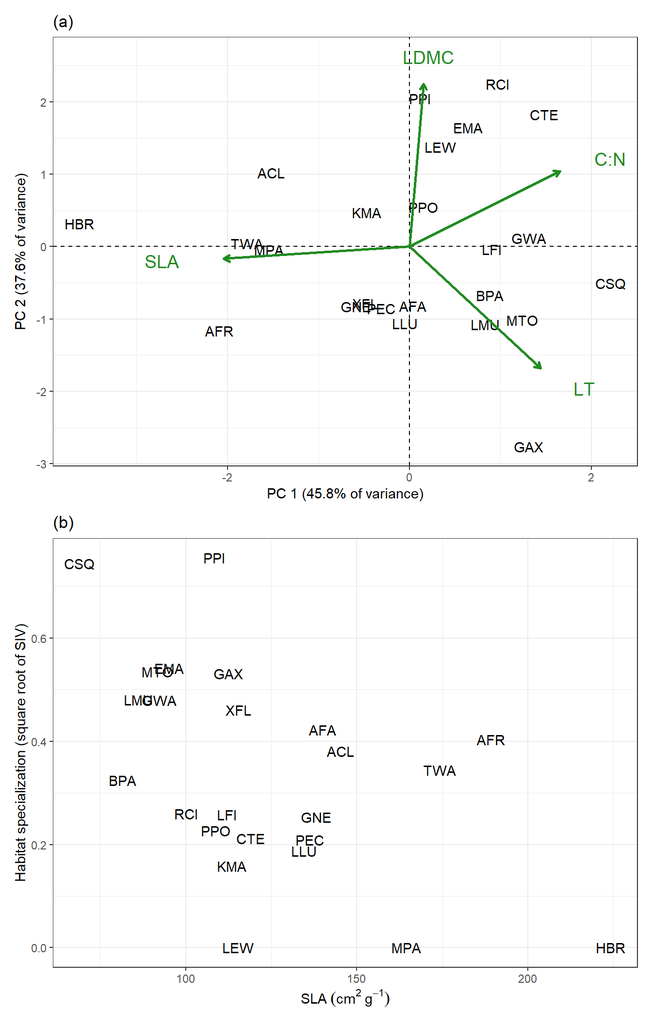

**Fig. 4** (corrected). (a) First and second principal components of four leaf traits of 24 species (C:N ratio from fresh leaves); (b) square root of the swamp indicator value against SLA.

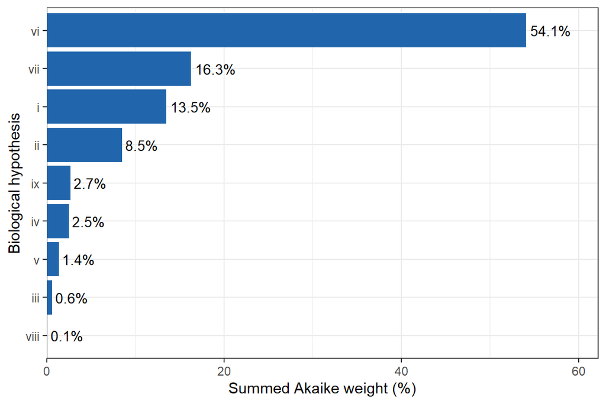

**Fig. 5** (corrected). Summed Akaike weights of the biological hypotheses. The four best supported, as shown with their path diagrams in the original Fig. 5, are now vi (54.1%), vii (16.3%), i (13.5%), ii (8.5%).

**Table S1** (corrected). Changed row in bold: Madhuca tomentosa.

| Species | Code | Duration (weeks) | Litter (g) | BA (cm²) | Plots | Production (g m⁻² yr⁻¹) | Productivity (g m⁻² yr⁻¹ m⁻² BA) |
| --- | --- | --- | --- | --- | --- | --- | --- |
| Adenanthera malayana | AMA | 49 | 342.9 | 2951.3 | 1 | 91.0 | 308.3 |
| Alstonia pneumatophora | APN | 40 | 135.1 | 1385.4 | 1 | 43.9 | 316.9 |
| Aporosa falcifera | AFA | 28 | 34.7 | 502.7 | 1 | 16.1 | 320.3 |
| Aporosa frutescens | AFR | 49 | 194.7 | 480.1 | 6 | 8.6 | 179.1 |
| Aporosa prainiana | APR | 40 | 120.7 | 247.3 | 1 | 39.2 | 1585.4 |
| Archidendron clypearia | ACL | 48 | 291.3 | 642.6 | 3 | 26.3 | 409.3 |
| Artocarpus kemando | AKE | 52 | 589.9 | 1862.4 | 1 | 147.5 | 792.0 |
| Bhesa paniculata | BPA | 50 | 741.9 | 5381.6 | 4 | 48.2 | 89.6 |
| Calophyllum tetrapterum var. tetrapterum | CTE | 50 | 145.9 | 490.9 | 1 | 37.9 | 772.1 |
| Campnosperma squamatum | CSQ | 53 | 1748.7 | 5382.4 | 4 | 107.2 | 199.2 |
| Canarium pilosum | CPI | 50 | 110.6 | 232.4 | 1 | 28.8 | 1239.5 |
| Diospyros maingayi | DMA | 52 | 488.0 | 2884.3 | 1 | 122.0 | 423.0 |
| Elaeocarpus mastersii | EMA | 46 | 95.3 | 1157.8 | 3 | 9.0 | 77.7 |
| Gironniera nervosa | GNE | 52 | 712.0 | 894.3 | 6 | 29.7 | 332.1 |
| Gluta wallichii | GWA | 49 | 338.4 | 3215.1 | 2 | 44.9 | 139.7 |
| Gynotroches axillaris | GAX | 26 | 42.8 | 1807.7 | 2 | 10.7 | 59.2 |
| Hevea brasiliensis | HBR | 18 | 13.8 | 111.2 | 1 | 10.0 | 899.1 |
| Knema malayana | KMA | 14 | 4.1 | 607.2 | 2 | 1.9 | 31.3 |
| Lindera lucida | LLU | 41 | 144.1 | 620.2 | 1 | 45.7 | 736.9 |
| Lithocarpus ewyckii | LEW | 50 | 805.6 | 156.0 | 1 | 209.4 | 13421.4 |
| Litsea firma | LFI | 46 | 28.9 | 886.7 | 1 | 8.2 | 92.5 |
| Lophopetalum multinervium | LMU | 44 | 422.1 | 6655.6 | 3 | 41.6 | 62.5 |
| Maasia glauca | MGL | 48 | 97.1 | 673.8 | 1 | 26.3 | 390.3 |
| **Madhuca tomentosa** | MTO | 50 | 699.7 | 10057.8 | 5 | 36.4 | 36.2 |
| Mallotus paniculatus | MPA | 10 | 2.9 | 51.5 | 1 | 3.8 | 737.4 |
| Pentace triptera | PTR | 46 | 396.7 | 503.9 | 2 | 56.1 | 1113.3 |
| Pometia pinnata | PPI | 53 | 697.3 | 7466.7 | 4 | 42.8 | 57.3 |
| Prunus polystachya | PPO | 49 | 1899.6 | 3075.9 | 3 | 168.0 | 546.2 |
| Pternandra echinata | PEC | 47 | 32.3 | 777.9 | 1 | 8.9 | 114.4 |
| Rhodamnia cinerea | RCI | 50 | 298.8 | 6633.9 | 3 | 25.9 | 39.0 |
| Sterculia cordata | SCO | 41 | 94.2 | 680.2 | 2 | 14.9 | 219.1 |
| Sterculia macrophylla | SMA | 53 | 18.5 | 498.8 | 1 | 4.5 | 90.2 |
| Timonius wallichianus | TWA | 41 | 192.6 | 768.2 | 5 | 12.2 | 158.8 |
| Xanthophyllum flavescens | XFL | 50 | 453.6 | 3649.6 | 5 | 23.6 | 64.7 |

**Table S3** (corrected).

| model | BA | Plot type | SLA | LT | LDMC | C:N | SIV | PC1 | PC2 | df | logLik | AICc | delta | weight | adj. R² |
| --- | --- | --- | --- | --- | --- | --- | --- | --- | --- | --- | --- | --- | --- | --- | --- |
| L8.2c | 0.92 (±0.17) | NA | NA | 1.71 (±4.64) | NA | NA | -1.41 (±1.52) | NA | NA | 9 | -131.849 | 284.801 | 0.000 | 0.200 | 0.367 |
| L8.3c | 0.92 (±0.17) | NA | NA | NA | 1.30 (±3.79) | NA | -1.12 (±1.47) | NA | NA | 9 | -132.063 | 285.229 | 0.427 | 0.162 | 0.366 |
| L2 | 0.89 (±0.18) | NA | NA | 0.39 (±4.35) | NA | NA | NA | NA | NA | 8 | -133.541 | 285.522 | 0.721 | 0.140 | 0.359 |
| L3 | 0.89 (±0.17) | NA | NA | NA | 1.75 (±3.67) | NA | NA | NA | NA | 8 | -133.599 | 285.640 | 0.838 | 0.132 | 0.361 |
| L2t | 0.91 (±0.18) | -0.45 (±0.49) | NA | 2.12 (±4.68) | NA | NA | NA | NA | NA | 9 | -132.920 | 286.944 | 2.143 | 0.069 | 0.368 |
| L7 | 0.92 (±0.17) | NA | NA | NA | NA | NA | -1.19 (±1.43) | NA | NA | 8 | -134.361 | 287.163 | 2.362 | 0.062 | 0.366 |
| L3t | 0.92 (±0.18) | -0.33 (±0.46) | NA | NA | 1.10 (±3.77) | NA | NA | NA | NA | 9 | -133.202 | 287.507 | 2.705 | 0.052 | 0.367 |
| L0 | 0.89 (±0.17) | NA | NA | NA | NA | NA | NA | NA | NA | 7 | -135.924 | 287.715 | 2.914 | 0.047 | 0.360 |
| L8.1c | 0.93 (±0.19) | NA | 0.10 (±1.07) | NA | NA | NA | -1.10 (±1.61) | NA | NA | 9 | -133.379 | 287.862 | 3.060 | 0.043 | 0.365 |
| L1 | 0.92 (±0.19) | NA | 0.35 (±0.97) | NA | NA | NA | NA | NA | NA | 8 | -134.981 | 288.402 | 3.601 | 0.033 | 0.361 |
| L0t | 0.92 (±0.18) | -0.36 (±0.45) | NA | NA | NA | NA | NA | NA | NA | 8 | -135.482 | 289.404 | 4.602 | 0.020 | 0.366 |
| L1t | 0.93 (±0.20) | -0.35 (±0.48) | 0.06 (±1.03) | NA | NA | NA | NA | NA | NA | 9 | -134.537 | 290.177 | 5.376 | 0.014 | 0.366 |
| L8.5c | 0.92 (±0.19) | NA | NA | NA | NA | NA | -1.20 (±1.59) | 0.01 (±0.28) | NA | 9 | -134.730 | 290.563 | 5.761 | 0.011 | 0.365 |
| L8.6c | 0.93 (±0.17) | NA | NA | NA | NA | NA | -1.23 (±1.47) | NA | -0.00 (±0.22) | 9 | -134.985 | 291.073 | 6.271 | 0.009 | 0.365 |
| L8.4c | 0.93 (±0.18) | NA | NA | NA | NA | -0.01 (±0.04) | -1.17 (±1.47) | NA | NA | 9 | -136.650 | 294.404 | 9.602 | 0.002 | 0.366 |
| L4 | 0.90 (±0.18) | NA | NA | NA | NA | -0.01 (±0.04) | NA | NA | NA | 8 | -138.221 | 294.883 | 10.082 | 0.001 | 0.360 |
| N3 | NA | NA | NA | NA | 4.17 (±3.65) | NA | NA | NA | NA | 7 | -140.200 | 296.266 | 11.465 | 0.001 | 0.203 |
| N8.3c | NA | NA | NA | NA | 4.02 (±3.68) | NA | 0.38 (±1.36) | NA | NA | 8 | -138.956 | 296.353 | 11.551 | 0.001 | 0.203 |
| L4t | 0.93 (±0.18) | -0.36 (±0.45) | NA | NA | NA | -0.01 (±0.04) | NA | NA | NA | 9 | -137.780 | 296.664 | 11.863 | 0.001 | 0.367 |
| N8.2c | NA | NA | NA | 1.66 (±4.36) | NA | NA | 0.40 (±1.45) | NA | NA | 8 | -139.287 | 297.015 | 12.213 | 0.000 | 0.189 |
| N2 | NA | NA | NA | 1.93 (±4.14) | NA | NA | NA | NA | NA | 7 | -140.595 | 297.058 | 12.256 | 0.000 | 0.189 |
| N8.1c | NA | NA | -1.72 (±1.07) | NA | NA | NA | -0.44 (±1.54) | NA | NA | 8 | -139.495 | 297.431 | 12.630 | 0.000 | 0.218 |
| N1 | NA | NA | -1.60 (±0.96) | NA | NA | NA | NA | NA | NA | 7 | -140.881 | 297.628 | 12.826 | 0.000 | 0.217 |
| N1t | NA | -0.79 (±0.54) | -2.00 (±1.00) | NA | NA | NA | NA | NA | NA | 8 | -139.703 | 297.847 | 13.046 | 0.000 | 0.239 |
| N3t | NA | -0.44 (±0.51) | NA | NA | 4.14 (±3.60) | NA | NA | NA | NA | 8 | -139.714 | 297.869 | 13.068 | 0.000 | 0.208 |
| N2t | NA | -0.53 (±0.54) | NA | 3.13 (±4.31) | NA | NA | NA | NA | NA | 8 | -139.917 | 298.275 | 13.473 | 0.000 | 0.199 |
| N7 | NA | NA | NA | NA | NA | NA | 0.54 (±1.38) | NA | NA | 7 | -141.737 | 299.341 | 14.540 | 0.000 | 0.188 |
| N0 | NA | NA | NA | NA | NA | NA | NA | NA | NA | 6 | -143.026 | 299.430 | 14.628 | 0.000 | 0.187 |
| N0t | NA | -0.43 (±0.52) | NA | NA | NA | NA | NA | NA | NA | 7 | -142.532 | 300.930 | 16.129 | 0.000 | 0.192 |
| N8.5c | NA | NA | NA | NA | NA | NA | -0.30 (±1.53) | 0.34 (±0.27) | NA | 8 | -141.376 | 301.192 | 16.390 | 0.000 | 0.207 |
| N8.6c | NA | NA | NA | NA | NA | NA | 0.54 (±1.37) | NA | 0.13 (±0.21) | 8 | -142.215 | 302.871 | 18.070 | 0.000 | 0.193 |
| N4 | NA | NA | NA | NA | NA | 0.02 (±0.04) | NA | NA | NA | 7 | -145.190 | 306.247 | 21.446 | 0.000 | 0.192 |
| N8.4c | NA | NA | NA | NA | NA | 0.02 (±0.04) | 0.36 (±1.41) | NA | NA | 8 | -143.917 | 306.275 | 21.473 | 0.000 | 0.192 |
| N4t | NA | -0.43 (±0.50) | NA | NA | NA | 0.02 (±0.04) | NA | NA | NA | 8 | -144.719 | 307.878 | 23.077 | 0.000 | 0.198 |

## Data availability

The species-level data deposited on Figshare (https://figshare.com/articles/dataset/Habitat_adaptation_mediates_the_influence_of_leaf_traits_on_canopy_productivity_evidence_from_a_tropical_freshwater_swamp_forest/15163782) contain the original, mixed C:N ratios. A new version of the dataset will give fresh-leaf C:N ratios, and the C and N content of fresh and senesced leaves separately.

# Afternotes for co-authors

These notes are not part of the erratum.

## Afternote 1. How the corrections were applied

The corrections were applied one at a time, so that each effect can be seen on its own. Scenario A reproduces the published analysis: all 108 SEMs have the same rank and weight as in `historical_reproduction.Rmd`, with AICc values within 0.002 (the third decimal, where `AIC.psem()` rounds).

| Scenario | Description | Species | Species–plot rows | PC1 (%) | PC2 (%) |
| --- | --- | --- | --- | --- | --- |
| A | As published. | 25 | 69 | 48.3 | 38.7 |
| A24 | A without Pentace triptera (PTR), which has no fresh-leaf C:N; isolates the smaller species set. | 24 | 67 | 49.2 | 37.7 |
| B1-ovr | Fresh-leaf C:N, 24 species, historical CTE override kept; isolates the fresh-leaf values. | 24 | 67 | 45.8 | 37.6 |
| B1 | Fresh-leaf C:N, 24 species, CTE at its measured value, model 55 fixed. | 24 | 67 | 45.8 | 37.6 |
| B2 | B1 plus the Madhuca fix (Q6 row restored). The corrected analysis if CTE’s samples were fresh. | 24 | 68 | 45.8 | 37.6 |
| B2-CTE | B2 with CTE excluded. The corrected analysis if CTE’s samples were not fresh. | 23 | 67 | 49.4 | 36.0 |

Decisions behind these steps: *Pentace triptera* has no fresh-leaf C:N, so it is dropped from every SEM, because AICc can only compare models fitted to the same data (imputing its C:N is an alternative to consider). As in the original analysis, species C:N is the mean of the per-sample ratios. The square-root transformation of SIV and the inverse-plot-number weights are kept, because they are part of the published model rather than errors.

## Afternote 2. Claim by claim

[output not shown]

## Afternote 3. Species C:N

| Species | Code | Fresh samples | Senesced samples | Samples used originally | C:N, published | C:N, fresh only | Difference |
| --- | --- | --- | --- | --- | --- | --- | --- |
| Campnosperma squamatum | CSQ | 2 | 2 | fresh + senesced | 50.23 | 34.65 | -15.59 |
| Gluta wallichii | GWA | 2 | 2 | fresh + senesced | 48.32 | 33.23 | -15.09 |
| Pometia pinnata | PPI | 2 | 2 | fresh + senesced | 43.14 | 31.81 | -11.34 |
| Madhuca tomentosa | MTO | 2 | 5 | fresh + senesced | 37.62 | 28.24 | -9.38 |
| Rhodamnia cinerea | RCI | 2 | 2 | fresh + senesced | 47.76 | 38.94 | -8.82 |
| Prunus polystachya | PPO | 2 | 2 | fresh + senesced | 34.82 | 26.84 | -7.99 |
| Lophopetalum multinervium | LMU | 2 | 2 | fresh + senesced | 31.26 | 24.26 | -7.00 |
| Archidendron clypearia | ACL | 2 | 2 | fresh + senesced | 23.78 | 19.15 | -4.62 |
| Xanthophyllum flavescens | XFL | 2 | 2 | fresh + senesced | 19.94 | 17.03 | -2.90 |
| Gironniera nervosa | GNE | 2 | 2 | fresh + senesced | 20.72 | 17.83 | -2.89 |
| Lithocarpus ewyckii | LEW | 2 | 2 | fresh + senesced | 32.90 | 32.45 | -0.45 |
| Bhesa paniculata | BPA | 2 | 2 | fresh + senesced | 26.08 | 25.98 | -0.10 |
| Aporosa falcifera | AFA | 2 | 0 | fresh only | 29.14 | 29.14 | 0.00 |
| Aporosa frutescens | AFR | 2 | 0 | fresh only | 20.68 | 20.68 | 0.00 |
| Calophyllum tetrapterum var. tetrapterum | CTE | 2 | 0 | fresh only | 49.84 | 49.84 | 0.00 |
| Elaeocarpus mastersii | EMA | 2 | 0 | fresh only | 33.14 | 33.14 | 0.00 |
| Gynotroches axillaris | GAX | 2 | 0 | fresh only | 29.17 | 29.17 | 0.00 |
| Hevea brasiliensis | HBR | 2 | 0 | fresh only | 12.87 | 12.87 | 0.00 |
| Knema malayana | KMA | 2 | 0 | fresh only | 24.69 | 24.69 | 0.00 |
| Litsea firma | LFI | 2 | 0 | fresh only | 28.65 | 28.65 | 0.00 |
| Lindera lucida | LLU | 2 | 0 | fresh only | 25.60 | 25.60 | 0.00 |
| Mallotus paniculatus | MPA | 2 | 0 | fresh only | 16.18 | 16.18 | 0.00 |
| Pternandra echinata | PEC | 2 | 0 | fresh only | 28.90 | 28.90 | 0.00 |
| Timonius wallichianus | TWA | 2 | 0 | fresh only | 24.92 | 24.92 | 0.00 |
| Pentace triptera | PTR | 0 | 2 | senesced only | 46.37 | NA | NA |

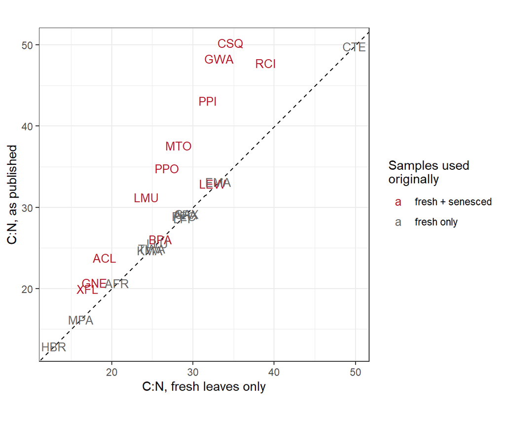

Species C:N used in the published analysis against fresh-leaf C:N (1:1 line dashed). PTR has no fresh-leaf value.

## Afternote 4. Step by step

Path coefficients [95% Wald CI] by scenario.

| path | A | A24 | B1-ovr | B1 | B2 | B2-CTE |
| --- | --- | --- | --- | --- | --- | --- |
| SLA -> SIV | -0.291 [-0.414, -0.167]; R² 24.1% | -0.293 [-0.412, -0.174]; R² 26.3% | -0.293 [-0.412, -0.174]; R² 26.3% | -0.293 [-0.412, -0.174]; R² 26.3% | -0.293 [-0.411, -0.174]; R² 26.3% | -0.295 [-0.412, -0.178]; R² 27.2% |
| LT -> SIV | 1.195 [0.438, 1.953]; R² 12.5% | 1.114 [0.364, 1.863]; R² 11.5% | 1.114 [0.364, 1.863]; R² 11.5% | 1.114 [0.364, 1.863]; R² 11.5% | 1.114 [0.370, 1.858]; R² 11.5% | 1.084 [0.336, 1.832]; R² 11.0% |
| LDMC -> SIV | -0.557 [-1.230, 0.116]; R² 3.8% | -0.388 [-1.076, 0.300]; R² 1.8% | -0.388 [-1.076, 0.300]; R² 1.8% | -0.388 [-1.076, 0.300]; R² 1.8% | -0.388 [-1.071, 0.295]; R² 1.8% | -0.333 [-1.027, 0.361]; R² 1.3% |
| CNratio -> SIV | 0.009 [0.004, 0.013]; R² 18.3% | 0.012 [0.008, 0.016]; R² 31.7% | 0.013 [0.006, 0.020]; R² 16.3% | 0.006 [0.000, 0.012]; R² 6.2% | 0.006 [0.000, 0.012]; R² 6.2% | 0.013 [0.006, 0.020]; R² 17.0% |
| PC1 -> SIV | 0.071 [0.039, 0.103]; R² 21.8% | 0.079 [0.049, 0.110]; R² 28.8% | 0.073 [0.040, 0.105]; R² 22.5% | 0.073 [0.040, 0.105]; R² 22.5% | 0.073 [0.040, 0.105]; R² 22.5% | 0.079 [0.048, 0.110]; R² 27.7% |
| PC2 -> SIV | -0.042 [-0.081, -0.002]; R² 6.1% | -0.025 [-0.065, 0.016]; R² 2.2% | -0.024 [-0.065, 0.016]; R² 2.1% | -0.024 [-0.065, 0.016]; R² 2.1% | -0.024 [-0.065, 0.016]; R² 2.1% | -0.013 [-0.055, 0.029]; R² 0.6% |
| SIV -> LDMC | -0.068 [-0.150, 0.014]; R² 3.8% | -0.048 [-0.132, 0.037]; R² 1.8% | -0.048 [-0.132, 0.037]; R² 1.8% | -0.048 [-0.132, 0.037]; R² 1.8% | -0.048 [-0.131, 0.036]; R² 1.8% | -0.040 [-0.124, 0.044]; R² 1.3% |
| SIV -> canopy | -1.668 [-4.373, 1.038] | -1.248 [-4.075, 1.579] | -1.248 [-4.075, 1.579] | -1.248 [-4.075, 1.579] | -1.186 [-3.990, 1.618] | -1.069 [-3.931, 1.793] |
| BA -> canopy | 0.932 [0.612, 1.252] | 0.917 [0.578, 1.256] | 0.917 [0.578, 1.256] | 0.917 [0.578, 1.256] | 0.924 [0.588, 1.259] | 0.925 [0.586, 1.264] |

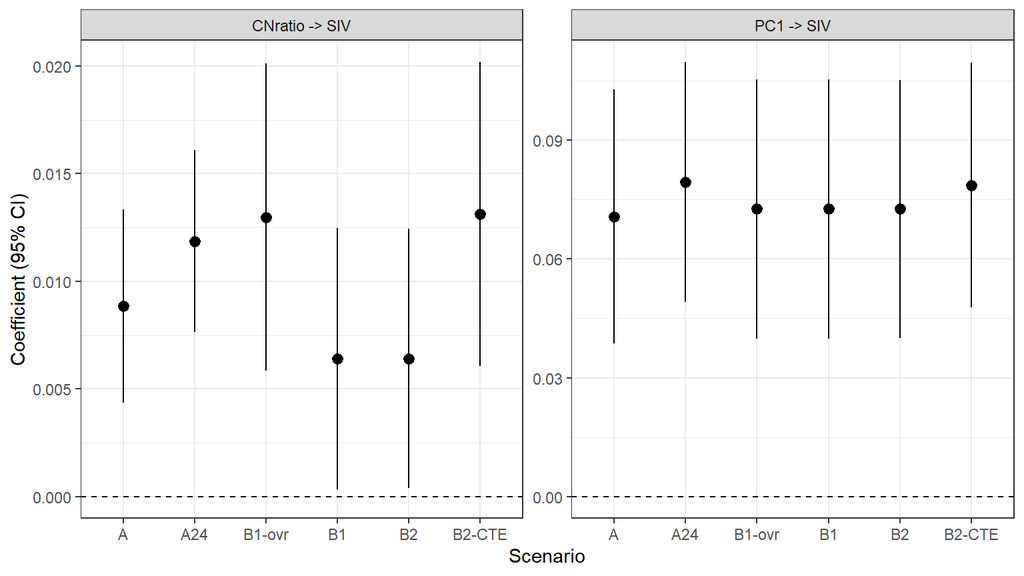

C:N → SIV and PC1 → SIV coefficients (95% CI) by scenario.

PCA loadings by scenario (signs aligned with A).

| trait | PC1 A | PC1 A24 | PC1 B1-ovr | PC1 B1 | PC1 B2 | PC1 B2-CTE | PC2 A | PC2 A24 | PC2 B1-ovr | PC2 B1 | PC2 B2 | PC2 B2-CTE |
| --- | --- | --- | --- | --- | --- | --- | --- | --- | --- | --- | --- | --- |
| SLA | -0.67 | -0.67 | -0.68 | -0.68 | -0.68 | -0.66 | 0.07 | 0.01 | -0.06 | -0.06 | -0.06 | -0.11 |
| LDMC | 0.18 | 0.12 | 0.05 | 0.05 | 0.05 | 0.02 | 0.73 | 0.75 | 0.75 | 0.75 | 0.75 | 0.78 |
| LT | 0.38 | 0.42 | 0.48 | 0.48 | 0.48 | 0.48 | -0.63 | -0.60 | -0.56 | -0.56 | -0.56 | -0.54 |
| CNratio | 0.61 | 0.60 | 0.55 | 0.55 | 0.55 | 0.58 | 0.26 | 0.27 | 0.35 | 0.35 | 0.35 | 0.30 |

Top ten SEMs by scenario: hypothesis, trait (Akaike weight).

| rank | A | A24 | B1-ovr | B1 | B2 | B2-CTE |
| --- | --- | --- | --- | --- | --- | --- |
| 1 | vi SLA (0.313) | vi SLA (0.184) | vi PC1 (0.204) | vi PC1 (0.217) | vi PC1 (0.226) | vi SLA (0.198) |
| 2 | vi PC1 (0.162) | vi CNratio (0.160) | vi SLA (0.168) | vi SLA (0.179) | vi SLA (0.191) | vi PC1 (0.156) |
| 3 | i SLA (0.082) | vi PC1 (0.112) | vi CNratio (0.088) | vii LDMC (0.092) | vii LDMC (0.092) | vii LDMC (0.088) |
| 4 | vii LDMC (0.071) | vii LDMC (0.094) | vii LDMC (0.086) | vii PC2 (0.072) | vii PC2 (0.069) | vii PC2 (0.076) |
| 5 | vi LT (0.063) | vi LT (0.067) | vii PC2 (0.067) | vi LT (0.065) | vi LT (0.059) | vi CNratio (0.074) |
| 6 | i PC1 (0.062) | i CNratio (0.061) | vi LT (0.061) | i PC1 (0.050) | i PC1 (0.053) | vi LT (0.051) |
| 7 | ii LDMC (0.057) | ii LDMC (0.050) | i PC1 (0.047) | ii LDMC (0.048) | i SLA (0.047) | i SLA (0.049) |
| 8 | vi CNratio (0.043) | i SLA (0.045) | ii LDMC (0.045) | vi CNratio (0.046) | ii LDMC (0.047) | ii LDMC (0.040) |
| 9 | vi PC2 (0.022) | vii PC2 (0.041) | i SLA (0.042) | i SLA (0.044) | vi CNratio (0.040) | i PC1 (0.040) |
| 10 | i LT (0.020) | i PC1 (0.038) | ii PC2 (0.039) | ii PC2 (0.041) | ii PC2 (0.038) | ii PC2 (0.038) |

Ranks (and weights) of the ten published top models.

| id | BH | trait | plotType | rank_A | rank_A24 | weight_A24 | rank_B1-ovr | weight_B1-ovr | rank_B1 | weight_B1 | rank_B2 | weight_B2 | rank_B2-CTE | weight_B2-CTE |
| --- | --- | --- | --- | --- | --- | --- | --- | --- | --- | --- | --- | --- | --- | --- |
| 13 | vi | SLA | noPlot | 1 | 1 | 0.184 | 2 | 0.168 | 2 | 0.179 | 2 | 0.191 | 1 | 0.198 |
| 17 | vi | PC1 | noPlot | 2 | 3 | 0.112 | 1 | 0.204 | 1 | 0.217 | 1 | 0.226 | 2 | 0.156 |
| 1 | i | SLA | noPlot | 3 | 8 | 0.045 | 9 | 0.042 | 9 | 0.044 | 7 | 0.047 | 7 | 0.049 |
| 21 | vii | LDMC | noPlot | 4 | 4 | 0.094 | 4 | 0.086 | 3 | 0.092 | 3 | 0.092 | 3 | 0.088 |
| 14 | vi | LT | noPlot | 5 | 5 | 0.067 | 6 | 0.061 | 5 | 0.065 | 5 | 0.059 | 6 | 0.051 |
| 5 | i | PC1 | noPlot | 6 | 10 | 0.038 | 7 | 0.047 | 6 | 0.050 | 6 | 0.053 | 9 | 0.040 |
| 9 | ii | LDMC | noPlot | 7 | 7 | 0.050 | 8 | 0.045 | 7 | 0.048 | 8 | 0.047 | 8 | 0.040 |
| 16 | vi | CNratio | noPlot | 8 | 2 | 0.160 | 3 | 0.088 | 8 | 0.046 | 9 | 0.040 | 5 | 0.074 |
| 18 | vi | PC2 | noPlot | 9 | 13 | 0.018 | 13 | 0.016 | 12 | 0.017 | 12 | 0.015 | 18 | 0.010 |
| 2 | i | LT | noPlot | 10 | 12 | 0.021 | 12 | 0.019 | 11 | 0.020 | 11 | 0.019 | 13 | 0.016 |

Summed Akaike weights (%) per biological hypothesis.

| BH | A | A24 | B1-ovr | B1 | B2 | B2-CTE |
| --- | --- | --- | --- | --- | --- | --- |
| vi | 61.3 | 55.4 | 54.8 | 53.7 | 54.1 | 49.7 |
| i | 19.2 | 17.4 | 14.5 | 13.4 | 13.5 | 13.7 |
| vii | 9.3 | 13.7 | 15.5 | 16.6 | 16.3 | 16.6 |
| ii | 7.8 | 7.2 | 8.4 | 8.9 | 8.5 | 7.8 |
| ix | 1.1 | 1.9 | 2.4 | 2.6 | 2.7 | 3.0 |
| iv | 0.7 | 2.4 | 2.3 | 2.5 | 2.5 | 4.9 |
| v | 0.3 | 1.3 | 1.2 | 1.3 | 1.4 | 2.8 |
| iii | 0.1 | 0.6 | 0.5 | 0.6 | 0.6 | 1.2 |
| viii | 0.0 | 0.1 | 0.0 | 0.0 | 0.1 | 0.1 |

Rank (Akaike weight) of each C:N SEM without plot type.

| BH | A | A24 | B1-ovr | B1 | B2 | B2-CTE |
| --- | --- | --- | --- | --- | --- | --- |
| vi | 8 (0.043) | 2 (0.160) | 3 (0.088) | 8 (0.046) | 9 (0.040) | 5 (0.074) |
| i | 11 (0.020) | 6 (0.061) | 11 (0.031) | 16 (0.012) | 16 (0.010) | 12 (0.027) |
| ii | 18 (0.004) | 36 (0.000) | 39 (0.000) | 38 (0.000) | 37 (0.000) | 40 (0.000) |
| vii | 20 (0.003) | 33 (0.000) | 36 (0.000) | 31 (0.001) | 31 (0.001) | 35 (0.000) |
| ix | 40 (0.000) | 52 (0.000) | 46 (0.000) | 47 (0.000) | 46 (0.000) | 45 (0.000) |
| viii | 51 (0.000) | 41 (0.000) | 38 (0.000) | 51 (0.000) | 50 (0.000) | 38 (0.000) |
| iv | 67 (0.000) | 83 (0.000) | 58 (0.000) | 29 (0.001) | 29 (0.001) | 59 (0.000) |
| v | 70 (0.000) | 86 (0.000) | 59 (0.000) | 34 (0.001) | 34 (0.001) | 60 (0.000) |
| iii | 71 (0.000) | 87 (0.000) | 63 (0.000) | 40 (0.000) | 40 (0.000) | 64 (0.000) |

## Afternote 5. Why CTE matters

*Calophyllum tetrapterum* (CTE) is weakly associated with the swamp: its swamp indicator value ranks 18 of 25, and it contributes 1 species–plot row. Its two CHNS samples are filed with the fresh leaves, but their nitrogen content (0.96–1.01%) is below that of every other fresh sample (1.19–3.78%) and within the range of the senesced samples, and they were entered separately from the rest of the fresh block. The original analysis gave CTE the mean C:N of the other species in the models (“assign CTE the mean value for now”), which neutralised it. Taken at face value, CTE combines one of the highest C:N ratios (49.84) with a low SIV, which flattens the C:N–SIV slope: C:N → SIV is 0.006 [0.000, 0.012] with CTE (B2) and 0.013 [0.006, 0.020] without it (B2-CTE). With the historical override and fresh-leaf values for the other species (B1-ovr), it is 0.013 [0.006, 0.020]. The strength of the C:N result therefore depends on CTE rather than on the mixing of fresh and senesced leaves as such.

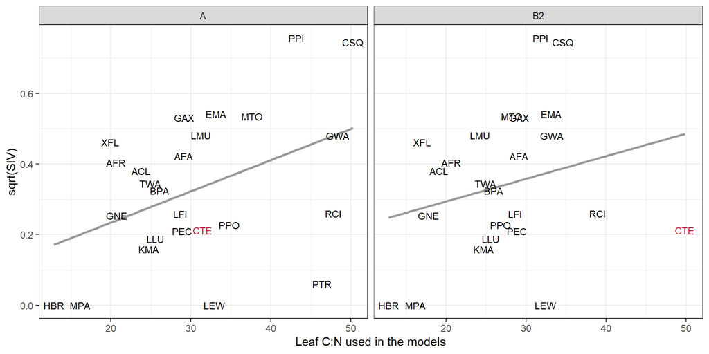

Square-rooted SIV against the species C:N used in the models, as published (A) and with fresh-leaf C:N (B2); CTE in red. Lines are unweighted least-squares fits, for orientation only.

**Question for WN and PJ:** were the two *C. tetrapterum* CHNS samples fresh or senesced leaves, and were they run in a later batch than the other fresh samples? If fresh, this document is knitted with `cte = "fresh"`; if not, with `cte = "excluded"`.

## Afternote 6. What kind of correction

Option

What

Assessment

1. Provenance note only

A note in the repository and a new Figshare version; nothing in the journal.

Insufficient: the Methods misdescribe the data, and published numbers (Table 1, Figs 4 and 5, coefficients, sample size) are wrong in the version of record.

2. Published correction

This erratum, plus a new Figshare version.

Proportionate: the errors change reported results but not the main conclusions.

3. Retraction or replacement

Withdraw or substantially republish.

Not warranted: hypothesis vi and the SLA, LT and PC1 effects are robust to the correction.

Under COPE guidance, a correction is the usual route when an honest error affects reported results without invalidating the conclusions; the decision rests with the authors and the journal’s editor.

## Afternote 7. Points for the authors to check

- The author list in the erratum heading is taken from the accepted manuscript; check it against the published version.
- The Introduction refers to “biological hypotheses viii–x” (l. 108), but there are nine hypotheses; the intended range should be confirmed before it is added to the erratum.
- The R version used originally is unknown: the paper gives 3.4.0, which cannot run piecewiseSEM 2.1.2. The erratum gives the version used for the corrected analysis.
- The SIV of *Madhuca* is the SSI file’s “Madhuca sp.” value. Whether it pools all *Madhuca* trees in the 40 plots could not be checked, because those data are not in this repository.
- Fisher’s C is computed here with `fisherC(dSep())` for every model, which can differ from `summary()` in the third decimal.
- The *Madhuca* fix has almost no effect on any result (compare B1 and B2).